# The Same Votes, Redrawn: Florida

Thirteen elections, twenty-eight districts, and a mid-decade map that never comes out behind

Democracy’s Data

Last updated 31 August 2026

## A claim worth checking

Florida’s legislature passed a new congressional map in 2026 with a stated goal: turn a 20-8 Republican delegation into a 24-4 one. That is not an opponent’s inference. It is the number the map’s own drafters have used in public, both before the vote and in court since.

Florida voters added language to the state constitution in 2010 specifically to prevent this. The Fair Districts Amendment bars drawing congressional districts with the intent to favor a political party. When voting-rights groups sued over the 2026 map on exactly that ground, the governor’s own counsel told lawmakers the amendment might not bind them anymore. He pointed to a Voting Rights Act case then pending before the U.S. Supreme Court (*Louisiana v. Callais*), and to a 2025 state Supreme Court ruling that had already narrowed the amendment’s reach. The state’s defense of its map, in short, leans less on “this map is fair” than on “the rule requiring fairness may no longer apply.”

No court has ruled on that question yet. A circuit court declined to block the map before the 2026 elections; the plaintiffs’ appeal of that decision was later dropped, and the underlying case continues. The map is nonetheless what today’s ballot is drawn on: August 18, 2026, is Florida’s primary day.

The map’s own stated goal is testable, and this chapter tests it. Florida replaced its congressional map in 2026, between censuses. The votes already cast in thirteen statewide elections can be re-counted inside both sets of lines. Same ballots, same totals; the only thing that changes is which district each precinct belongs to.

That re-count is the whole method here. If the new lines really were friendly to the party they are supposed to hurt, some election among the thirteen should elect more Democrats under them. You are about to see whether any does.

## The rule Florida wrote for itself

Florida’s problem is not the timing. Nothing in federal law limits how often a state may redraw, and Florida, unlike Missouri, North Carolina and Tennessee, has written no bar on mid-decade redistricting into its own law. A 2026 map was open to Florida the way a 2025 map was open to Texas.

What Florida wrote down instead is a rule about *why* a map may be drawn. Article III, sections 20 and 21 of its constitution say that “no apportionment plan or individual district shall be drawn with the intent to favor or disfavor a political party or an incumbent.” Voters put that there by initiative in 2010, after a decade of maps they thought had been drawn for exactly that reason.

**Florida is not alone in having such a rule, and it is alone in how hard the rule has been tested.** Eighteen states have some version of a prohibition on favoring or disfavoring a party, a candidate or an incumbent. In most of them it has never decided a case.

**In Florida it has already killed a congressional map.** In *League of Women Voters of Florida v. Detzner* (2015) the state Supreme Court upheld a finding against the 2012 congressional plan. It had been drawn with the intent to favor the Republican Party and its incumbents. The map was redrawn. The state Senate then conceded that its own 2012 plan had the same defect and would not be used. That is the precedent the state is now arguing has narrowed.

Now notice what the rule turns on, because it decides how to read everything below. **The Florida courts have held that the amendment does not forbid a partisan *effect*. It forbids a partisan *intent*.** A map that happens to help one party is not unconstitutional in Florida. A map drawn in order to help one party is.

Every number in this chapter measures effect. The re-count can show what the new lines do to votes already cast, and it can show it precisely. It cannot show why anybody drew them. What makes this case unusual is that the intent is not in dispute: the drafters named the seat count they wanted, in public, before the vote.

## Where the data comes from, and what it is for

The two spreadsheets behind this chapter come from Dave’s Redistricting, a free public site. It rebuilds American elections at the precinct level, the few thousand voters who share one polling place, and re-sums them inside any district map you load. One file carries the map Florida enacted in 2022; the other carries the 2026 replacement. Each holds the same thirteen statewide elections from 2016 through 2024.

**Who is in it, and how they got there.** Every voter who cast a countable vote for a Democratic or Republican candidate in those thirteen races. Their ballots entered the file through the official county canvasses, which the site’s volunteers collect and reconcile precinct by precinct.

**Who it was made for.** People who draw and judge district maps. The site exists so that anyone proposing a plan can see, before any election is held, how the votes already on record would fall inside it.

**What it costs to get.** Nothing but an account and patience. There is no address a script can call; each election is exported by hand from a browser with the right map open, which is why this chapter ships its copies.

**What has already been done to it.** Three things. Precincts that straddle a district line were split, with votes shared out in proportion to population. Each district’s votes were then reduced to a two-party share – the Democratic vote divided by the Democratic and Republican votes together, third parties set aside. And the same arithmetic was run twice, once per map, which is what makes the comparison possible.

That match was found once, by assigning all 390,066 of Florida’s 2020 census blocks into both plans. Each block’s population was carried into whichever pairing of old and new districts maximized the total carried across, with every district used exactly once on each side. It is a real correspondence, not a guess, but for the three renumbered districts it is a plurality, not a majority. The closing section says what that costs for the districts it affects most.

**A third source, for who lives there.** Dave’s Redistricting attaches population and race/ethnicity percentages to every district it exports, so the same map files behind the vote totals also carry who lives inside each district, under both plans. Nothing further was fetched to build Figure 5.

> **Before you scroll, make two predictions.** Across thirteen statewide elections, in how many does the new map elect more Republicans than the old one – and in how many does it elect fewer? Write both numbers down.

## Watch the lines move

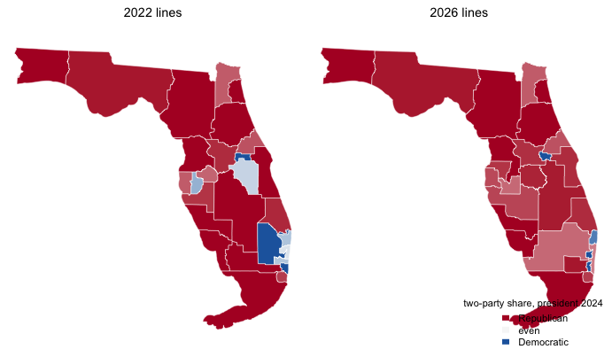

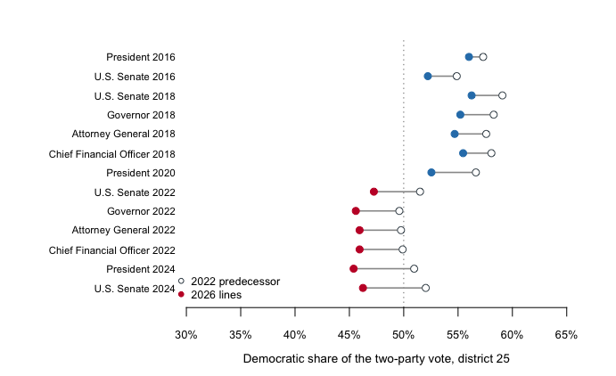

**Figure 1. Twenty-eight districts, two maps, one set of votes, and any one district’s full history.** The morph button slides every boundary from its 2022 position to its 2026 position; color re-counts whichever statewide race you select inside the lines shown. Click any district, or pick one from the District menu, to load all thirteen of its elections below the map, under both plans at once, its outline overlaid in the inset. Districts 22, 23, and 25 carry a note on hover – “mostly old district X” – because their 2026 outline is not the district their number pointed to in 2022. In print, the two plans sit side by side, colored by the 2024 presidential race, with district 25 below as the worked example.

## Thirteen elections, one direction

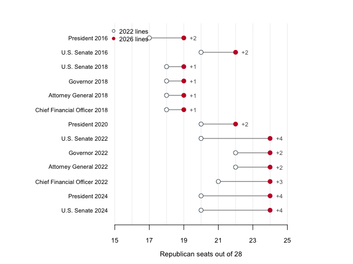

**Figure 2. The gain, race by race.** Each row re-counts one statewide election under both maps; the dot never moves left. Every one of the thirteen races elects more Republicans under the new lines, from 1 to 4 more seats. Under the 2024 presidential race specifically, Republican-won districts go from 20 to 24 of 28 – the same 20-to-24 swing the map’s own drafters have described publicly as the point of the exercise. Every row uses this chapter’s own office names, including `trea`, which this collection’s export shorthand names for Florida’s real Chief Financial Officer; Texas’s own version of this chapter has no matching office.

## Every district, every election

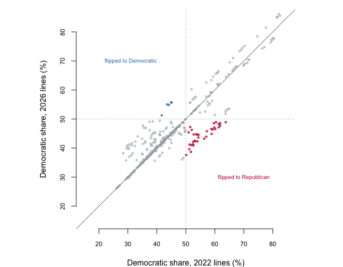

## Where each district’s people came from

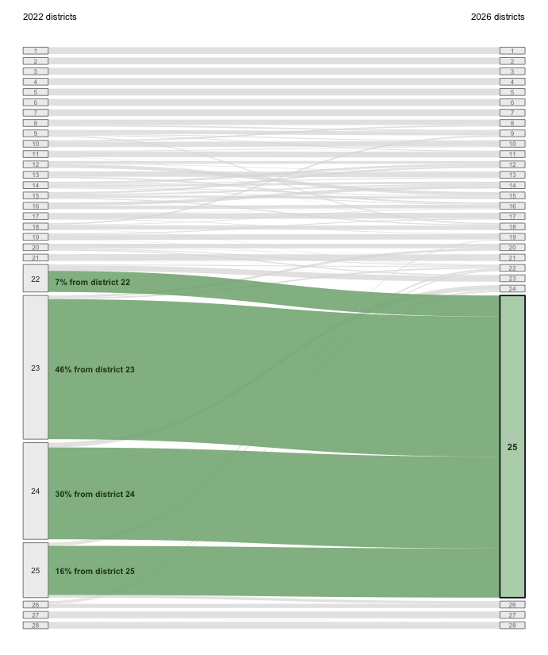

**Figure 4. Where one district’s people came from.** Every ribbon is a group of residents, leaving the 2022 district that held them and landing in the 2026 district that holds them now. One district is opened up to fill the frame while the other twenty-seven collapse to slivers, because twenty-eight districts at equal size leaves each one too thin to read. Opened here is district 25, which draws its people from the old 23rd (46%), the old 24th (30%), the district that carried its own number (16%), and the old 22nd (7%). That is four predecessors, where an untouched district would have one. Online, click any district or ribbon and the diagram re-opens around it.

## Who a district represents

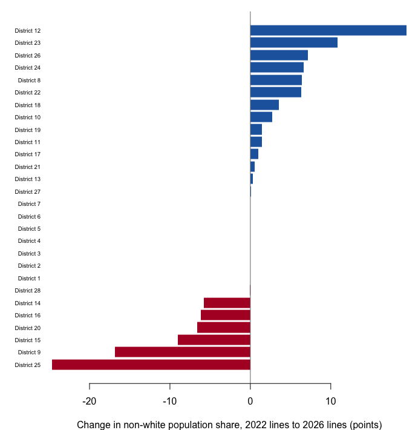

**Figure 5. Race and ethnicity, both maps, every district.** The static chart ranks all 28 districts by the change in non-white population share from the 2022 lines to the 2026 lines; blue districts gained non-white population, red districts lost it. In the online version, pick a district from the menu above the chart for its full composition, category by category, open circle to filled circle.

## What re-run elections cannot tell you

These thirteen races are statewide contests re-counted inside district lines, not district contests. A House race has its own candidates, its own money, and an incumbent voters know. This data does not carry that; it carries what a map’s drafters would answer with instead. Read it as that kind of evidence, and say so when you quote it.

And it is the wrong shape for the constitutional question. Florida’s rule is about intent, and a re-count is a measurement of effect. What this chapter can establish is that the 2026 lines move seats in one direction, in every election available. Whether they were drawn in order to is a question for the record of who drew them, not for these thirteen columns.

The re-count also holds turnout fixed. It assumes the people who voted in 2016 through 2024 are the people who will vote in 2026, in the same numbers, with the same loyalties. Districts full of voters who switched sides recently, like Florida’s newly redrawn 25th, are exactly where that assumption is weakest. The map’s authors are betting that recent returns are the new normal; the data here can describe the bet, but cannot settle it.

Florida carries one further limit that this chapter has already leaned on throughout. The population-weighted crosswalk translates each renumbered district into its 2022 predecessor, but for districts 22, 23, and 25 that translation is a single best match, not a full accounting of a district’s ancestry. The old 23rd, for instance, carries only 46.3% of the new 25th’s population. Treat those three districts’ per-election numbers as good evidence about where most of their people came from. They are not a claim that the 2022 and 2026 districts sharing a role are the same object, the way an untouched district genuinely is.

This population match is not the only way to pair the two maps. An earlier pass at the same problem, matching districts by shared land area instead, found seven districts renumbered, not three. Most of Florida’s redraw nibbled at lightly populated edges, moving lines without moving many people; where people actually live, only a tight rotation among three South Florida districts changed hands. Land and population can tell different stories about the same map, and population is the one that matches who actually lives there.

## Sources

**Data**

- District-level results for thirteen Florida statewide elections, 2016–2024, under the 2022 and 2026 congressional plans, from Dave’s Redistricting (https://davesredistricting.org), which rests on reconstructed precinct-level results from the official county canvasses. District boundary files for both plans come from the same site’s exports, and carry the population and race/ethnicity percentages behind Figure 5.
- 2020 Census population by block (`tl_2020_12_tabblock20`, U.S. Census Bureau TIGER/Line), used only to build the population-weighted district crosswalk described above – not to re-derive any vote total. https://www2.census.gov/geo/tiger/TIGER2020/TABBLOCK20/tl_2020_12_tabblock20.zip

**The data itself**

Every figure above is drawn from these tables. They are plain CSV, they open in a spreadsheet, and they are yours to take further.

`district_shares.csv`, `district_summary.csv`, `fl-districts-tween.json`, `fl_demographics.csv`, `fl_overlap_pop.csv`, `seats_by_election.csv`

**Your turn**

None of these is answered above, and every one can be answered from the tables you just opened.

- `seats_by_election.csv` replays thirteen elections on both maps. Count how often the new map does better for its authors, and by how much.
- `fl_demographics.csv` gives each district under each plan a `minority_pct`. Compare the two plans. Count the districts that cross a majority threshold in either direction.
- `district_summary.csv` has `pres2024_old` beside `pres2024_new`. Sort by the change. Which districts moved most, and were they the ones being helped or the ones being sacrificed?
- `fl_overlap_pop.csv` shows how much population each new district inherited from each old one. Find the districts that stayed put. What does an untouched district tell you about the ones that moved?

**Press**

- *Florida Politics* (2026). “Gov. DeSantis ignores Fair Districts amendment in congressional map, argues it’s already unconstitutional.” April 2026. The source for the governor’s counsel’s argument to lawmakers.
- *Florida Phoenix* (2026). “Counsel for DeSantis tells lawmakers they can ignore Fair Districts Amendments in approving new map.” April 28, 2026.
- State Court Report (2026). “Florida Courts and Politicians Ignored the People’s Message.” June 2026. Summarizes the litigation’s status as of that writing: no merits ruling yet, the preliminary-injunction denial under appeal, the map in place for 2026 regardless.
- *Florida Phoenix* (2026). “The Democratic race for CD 25: Jared Moskowitz vs. Oliver Larkin.” August 12, 2026.
- *Tampa Bay Times* (2026). “Democrats make their final pitch as they vie for Florida US Senate seat.” August 17, 2026.
- *Equal Ground Education Fund et al. v. Byrd et al.* (2026). Complaint, Circuit Court of the Second Judicial Circuit, Leon County, Florida, filed May 4, 2026 – one of several challenges to the 2026 congressional map under the Florida Constitution’s Fair Districts amendment. A preliminary injunction was denied May 26, 2026; the plaintiffs’ appeal was voluntarily dismissed June 24, 2026, and the map stands for the 2026 elections while the underlying case continues.

**Further reading**

- Ballotpedia (2026). “Florida gubernatorial and lieutenant gubernatorial election, 2026.” **Constitution and cases**
- Fla. Const. art. III, §§ 20-21 (the Fair Districts amendments, adopted by initiative in 2010).
- *League of Women Voters of Florida v. Detzner*, 172 So. 3d 363 (Fla. 2015) – the 2012 congressional plan held to have been drawn with the intent to favor a party and its incumbents.
- National Conference of State Legislatures, *Redistricting Law 2020* (Denver: NCSL, October 2019), ch. 4 for the eighteen states carrying a “favoring or disfavoring” prohibition, ch. 6 for *Detzner*, and ch. 10 for the states that bar mid-decade redistricting, which Florida does not. Frozen at 2019, so a state may have added or repealed such a rule since.

**Academic literature**

- Grofman, B. and King, G. (2007). “The Future of Partisan Symmetry as a Judicial Test for Partisan Gerrymandering after *LULAC v. Perry*.” *Election Law Journal* 6(1): 2–35.
- Cervas, J. and Grofman, B. (2020). “Tools for identifying partisan gerrymandering with an application to congressional districting in Pennsylvania.” *Political Geography* 76: 102069.

Why this data cannot be fetched again

```
The data behind this chapter cannot be downloaded again by a script, and
it is worth knowing why before you try.

WHY NOT. The two spreadsheets were exported from Dave's Redistricting
(https://davesredistricting.org), which rebuilds election results at
the precinct level and re-sums them inside any district map you load.
Each export is a manual download from a browser session with a
particular map open; there is no address a script can call to get the
same file. The copies shipped with this chapter are the archive.

WHAT EXISTS INSTEAD. The site itself, free after registration. Open
the enacted 2022 Florida congressional map and the 2026 replacement,
turn on any statewide election from 2016 through 2024, and the site
shows the same district-by-district shares these files hold. Exporting
them one election at a time rebuilds the two spreadsheets, columns for
president, governor, senator, and the rest, rows for districts 1
through 28.

ONE WRINKLE. Three of Florida's districts (22, 23, 25) were renumbered,
not just redrawn, as part of the 2026 map. This chapter's comparisons
match a 2026 district to its population-weighted predecessor, not the
2022 district sharing its number — build-block-crosswalk.R found that
pairing once, from 2020 census blocks, and it is not something
re-exporting the site's data will reproduce on its own.

WHAT YOU CAN STILL CHECK. However you come by the numbers, these say
whether you are holding the same object:
- 28 rows per file, one per district; 13 election columns; the long
  table assembled from them has 364 rows
- every cell is a Democratic share of the two-party vote, strictly
  between 0 and 1
- in the 2024 presidential race, Democratic candidates lead in 8
  districts under the 2022 lines and 4 under the 2026 lines
- across all 13 elections the 2026 lines never elect fewer Republicans
  than the 2022 lines; the gain runs from 1 seat to 4
```